# Linear models with R

Packages needed for linear model analysis and examples:

```r
library(palmerpenguins) # Example data
library(tidyverse) # Data manipulation
library(performance) # Model diagnostics
library(rstatix) # More friendly version of Tukey test
```

# 1 Intro

When you fit a linear model (an Anova is a type of linear model), you need to give the `lm` function a formula that describes the relationship between the response variable and the predictor variables in your data. This formula should reflect your hypothesis.

The formula is written as `y ~ x1 + x2 + ... + xn`, where `y` is the response variable and `x1`, `x2`, …, `xn` are the predictor variables.

Depending on the type of response variable, you can use `lm` to perform different linear model types:

- Regression model: `lm(y ~ x1)` with `x1` as a continuous variable
- ANOVA: `lm(y ~ x1)` with `x1` as categorical variables
- ANCOVA: `lm(y ~ x1 + x2)` with `x1` as a categorical variable and `x2` as a continuous variable

All these formulas can also contain interactions between the predictor variables. Interactions between predictor variables are written as `x1:x2`.

# 2 General workflow

To do a linear model analysis in R, you can follow these steps (see below for an example):

1. Explore the data and your hypothesis using a quick visualization
2. Fit the linear model according to your hypothesis using `lm`
3. Get a summary of the model using `summary`: Check out model coefficients and effect sizes
4. Check whether your explanatory variables are significant using `drop1`
5. Check model assumptions using diagnostic plots and checking functions
6. Take the plot from step 1, make it look nice and add the model fit.

# 3 Example 1: ANOVA

This example uses the `penguins` dataset from the `palmerpenguins` package.

- **Research question:** How does the penguin species and sex affect penguin body mass?
- **Hyphothesis:** The body mass of penguins is higher for male penguins and differs between species.

## 3.1 Explore the data

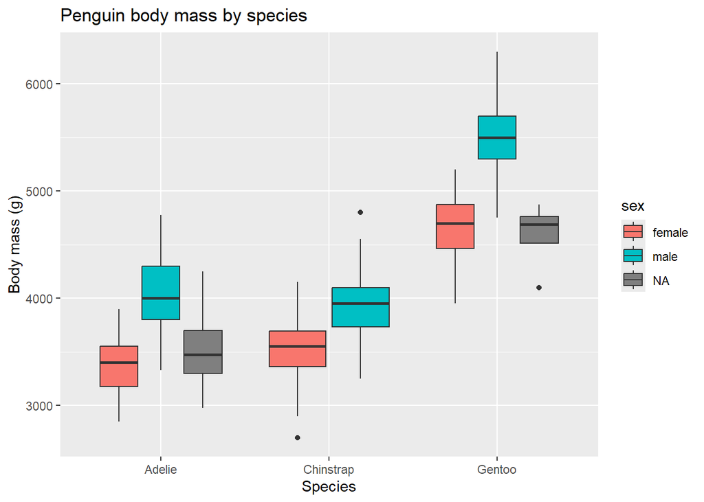

```r
ggplot(penguins, aes(x = species, y = body_mass_g, fill = sex)) +
  geom_boxplot() +
  labs(title = "Penguin body mass by species",
       x = "Species",
       y = "Body mass (g)")
```

## 3.2 Fit the linear model

I want to fit a linear model to test my hypothesis.

```r
# 2. Fit the linear model
penguin_lm <- lm(
  body_mass_g  ~ species + sex, # Model formula to test your hypothesis
  data = penguins  # Tibble containing the variables
  )
```

If we also wanted to test the interaction between `species` and `sex`, we have to add the interaction term to the model formula: `body_mass_g ~ species + sex + species:sex`.

## 3.3 Get a summary of the model

With the `summary` function, we can get model coefficients and effect sizes:

```r
# 3. Get a summary of the model
summary(penguin_lm)
```

[output not shown]

The model estimates can be found in the `Coefficients` table (column `Estimat Std`). In case of an ANOVA, the `Estimate` column contains the mean body mass for each species. It is a bit complex to disentangle, but the values in the rows mean:

- `(Intercept)`: The mean body mass of the female penguins of the first species (Adelie penguin)
- `speciesChinstrap`: The difference in body mass between female Adelie and Chinstrap penguins (Chinstrap = 3372 g + 27 g)
- `speciesGentoo`: The difference in body mass between female Adelie and Gentoo penguins (Gentoo = 3372 g + 1377 g)
- `sexmale`: The difference in body mass between female and male penguins

## 3.4 Check whether the explanatory variable is significant

To check whether both `species` and sex have a significant effect on body mass, we can use the `drop1` function with an F-test. With this test, we check whether the model would become significantly worse if we remove the predictors.

```r
# 4. Check whether the explanatory variable is significant
drop1(penguin_lm, test = "F")
```

```
Single term deletions

Model:
body_mass_g ~ species + sex
        Df Sum of Sq       RSS    AIC F value    Pr(>F)
<none>                32979185 3838.6
species  2 143401584 176380769 4392.9  715.29 < 2.2e-16 ***
sex      1  37090262  70069447 4087.5  370.01 < 2.2e-16 ***
---
Signif. codes:  0 '***' 0.001 '**' 0.01 '*' 0.05 '.' 0.1 ' ' 1
```

The p-value in both the species and the sex column of the result is < 0.05, which means that both species and sex are significant predictors of body mass. If we would remove these terms from the model, then the model would become significantly worse.

## 3.5 Check model assumptions

Linear models have 3 main assumptions that need to be fulfilled:

- normality of model residuals
- constant variance of model residuals
- no strong outliers

We need to check them for every model. If they are violated, then we have to use other types of models

### 3.5.1 Visual checks

We can the model assumptions using diagnostic plots:

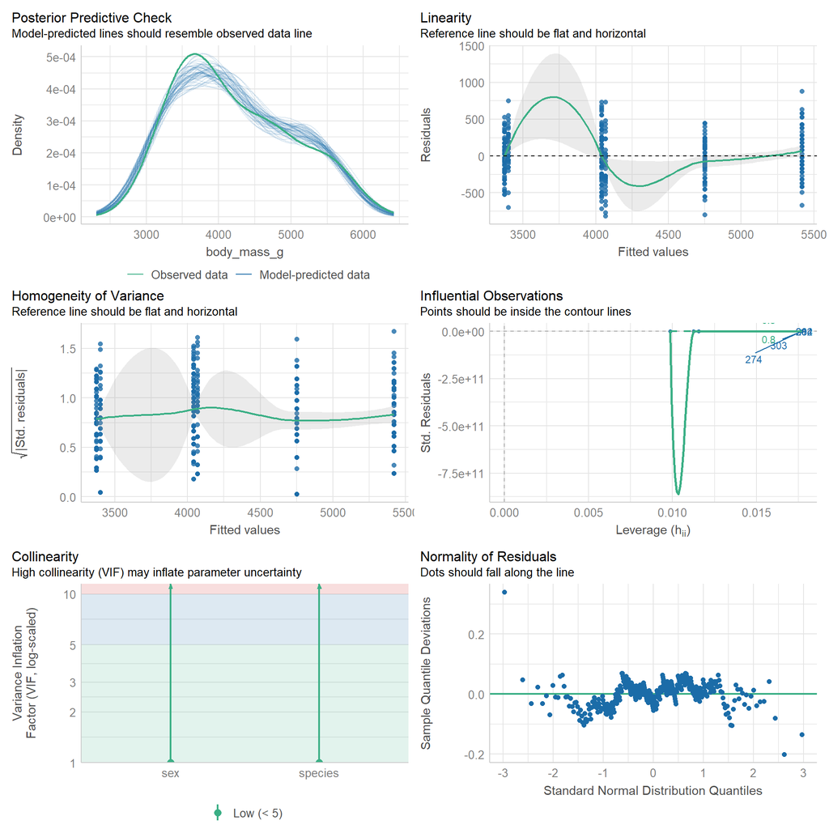

```r
performance::check_model(penguin_lm)
```

On top of each of the plots is written what you should look for. The data are never perfect, so small deviations are totally ok.

### 3.5.2 Other tests

You can also perform the most important checks manually and the results are printed in the console for you. They are also provided by the `performance` package:

```r
# Check for constant variance
performance::check_heteroscedasticity(penguin_lm)
```

```
OK: Error variance appears to be homoscedastic (p = 0.614).
```

```r
# Check for influential observations (outliers)
performance::check_outliers(penguin_lm)
```

```
OK: No outliers detected.
- Based on the following method and threshold: cook (0.5).
- For variable: (Whole model)
```

```r
# check normality of residuals
performance::check_normality(penguin_lm)
```

```
OK: residuals appear as normally distributed (p = 0.875).
```

If all these tests are ok, you can be confident that your model is valid.

## 3.6 Posthoc test to compare groups

If the ANOVA is significant, we can perform a posthoc test to compare the groups. For this, we can use the `tukey_hsd` function from the `rstatix` package. It is a wrapper around the `TukeyHSD` function from base R that makes the output more friendly. This function performs pairwise comparisons between the groups and corrects for multiple testing.

```r
# Posthoc test to compare groups
tukey_hsd(penguin_lm)
```

```
# A tibble: 4 × 9
  term    group1    group2    null.value estimate conf.low conf.high    p.adj
* <chr>   <chr>     <chr>          <dbl>    <dbl>    <dbl>     <dbl>    <dbl>
1 species Adelie    Chinstrap          0     26.9    -82.5      136. 8.31e- 1
2 species Adelie    Gentoo             0   1386.    1294.      1478. 5.09e-13
3 species Chinstrap Gentoo             0   1359.    1246.      1473. 5.09e-13
4 sex     female    male               0    667.     599.       736. 5.09e-13
# ℹ 1 more variable: p.adj.signif <chr>
```

# 4 Further reading

- [Book chapter on linear modelling](https://intro2r.com/simple_lm.html)